# Reproducible Research with R and RStudio

Chapter 4 - Getting Started with File Management

Emile Latour

August 24, 2016

# Introduction

Well organized files enable you to

- more easily make changes,
- benefit from work that you have already done, and
- collaborate with others.

Using tools such as R, *knitr/rmarkdown*, and markup languages like LaTeX require detailed knowledge of where files are stored in your computer.

# Introduction

To enable reproducibility, file management may require command line tools to access and organize files.

By typing commands, you are documenting all the steps that you take, which has a big advantage over clicking and dragging with a cursor.

# Introduction

In this chapter, we will:

1. Discuss how a reproducible research project may be organized.
2. Cover file path naming conventions.
3. Organize files with RStudio Projects.
4. Cover some basic R and Unix-like shell commands (Cover R only).
5. See how to navigate files in RStudio in the *Files* pane.

Discussion in this chapter focuses on files locally stored on your computer. As opposed to remotely stored in the cloud.

# File Trees

- Operating systems covered in the text organize files in **hierarchical directories**, aka **file trees**.
- **Directories** can be thought of as the folders that you see in Windows or Mac. Gandrud uses the terms “directory” and “folder” interchangeably.
- Directories are **hierarchcial** because they are located inside other directories.

# Project File Tree

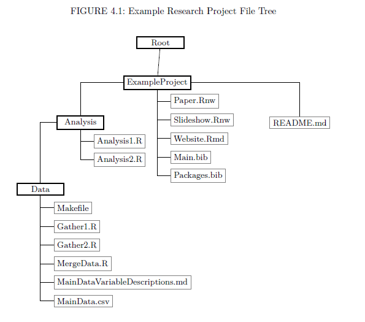

# Root directories

A **root directory** is the first level in a disk such as a hard drive.

Windows notation

```
C:\
```

Unix-like systems (Macs and Linux computers) notation

```
/
```

# Subdirectories & parent directories

Directories inside other directories are also referred to as **child directoires** of a **parent directory**.

# Windows file path in R

Windows computers separate sub-directories with the back slash (`\`). For example:

```r
C:\ExampleProject\Data
```

When you type a Windows file path in R, you need to use two backslashes rather than one:

```
C:\\ExampleProject\\Data
```

Another option for writing Windows file names in R is to use one forward slash (`/`).

```
C:/ExampleProject/Data
```

# Unix-like systems file path in R

Unix-like systems, including Mac computers, are indicate with a forward slash (`/`). For example:

```
/ExampleProject/Data
```

Note: in Unix-like systems, the forward slash (`/`) with nothing before it indicates the root directory.

```
/ExampleProject/Data # subdirectory of the root

ExampleProject/Data # subdirectory of the working directory
```

# Working directories

- **It is important to now what your current working directory is.**
- The **working directory** is the directory where the program automatically looks for the files and other directories, unless indicated otherwise.

More on this later.

# Absolute vs. relative paths

- It is a good idea to used **relative file paths** rather than absolute to make your code less dependent on the particular file structure of a different computer.
- Absolute file path specifies the child directory all the way back to the root directory

  ```
  /ExampleProject/Data
  ```

- Relative file path specifies the child relative to the working directory. So if the current working directory is *ExampleProject*, then

  ```
  Data/
  ```

# Spaces in directory & file names

- It is good practice to avoid spaces in file and directory names. Spaces can sometimes create problems for computer programs trying to read the file path.
- This would also apply to file names.
- A convention should be adopted that makes multi-word names easily readable without using spaces.

# Naming conventions

- The author suggests CamelBack as potential convention where new words are indicated with capital letters.

```r
# Examples of CamelBack
/ExampleProject/Data
fitModels.R
```

- [Google’s R Style Guide](https://google.github.io/styleguide/Rguide.xml) suggests using underscores for file names:

```r
# Underscore examples
/example_project/Data
fit_models.R
```

- [Hadley Wickham’s Style Guide](http://adv-r.had.co.nz/Style.html) suggests using dashes for file names:

```r
# Dash examples
/example-project/Data
fit-models.R
```

# Organizing your research project

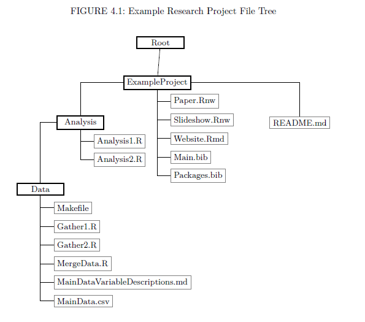

# Things to note in the example file tree

- Parent directory (*ExampleProject*) containing the primary knittable documents.
- Sub-directory (*Anlaysis*) containing the R files to run the analysis.
- Sub-directory (*Data*) containing the data and the R files to perform the data management.
- The nested file structure allows for use of relative file paths.

# README

- There is also a file *README.md* that gives an overview of all the files in the project. It should indicate/briefly describe:
  - Title, author(s), topic, copyright information, etc.
  - How the folders in the project are organized.
  - Instructions for how to reproduce the project.
- The README file should be stored in the main project folder.

# sessionInfo()

It is good practice to include the system information for the R session you used to create the project. This can be done by writing your README file in R Markdown and including the command `sessionInfo()` in a *knitr* code chunk.

[session information not shown]

# Setting directories as RStudio Projects

If using RStudio, you may want to organize files as a Project. The author gives steps to turn an existing directory into a project as follows:

1. Click on `File` in the RStudio menu bar.
2. Select `New Project` and a new window will pop up.
3. Select the option `Existing Directory`.
4. Click on the `Browse` button to find the directory that you want to turn into and RStudio Project.
5. Select `Create Project`.

Notice that RStudio has put a file with the extension `.Rproj` in the directory.

# RStudio Projects

- Reasons RStudio Projects are useful:
  - Easy to open.
  - When opening, RStudio automatically sets the working directory and loads the workspace, history, and source code that you were last working on.
  - You can set project specific options.
  - When you close the project, R workspace an history are save in the directory that you want.
  - Version control.
  - Makefiles allow you to build your project to run in a certain way.
  - Easy to use interface for managing R packages.

# R file manipulation commands

Commands for handling and navigating through files.

# `getwd`

Find your current working directory

```r
# Show the current working directory used when knitting this presentation.
getwd()
```

```
## [1] "H:/RRR-JC/RRRR_Chapter4_Latour"
```

# `list.files`

See all of the files and sub-directories in the current working directory.

```r
# See files in current working directory
list.files()
```

```
## [1] "images"                          "RRRR-Chapter-4-Outline.docx"
## [3] "RRRR-Chapter-4-Outline.html"     "RRRR-Chapter-4-Outline.pdf"
## [5] "RRRR-Chapter-4-Outline.Rmd"      "RRRR-Chapter4-Presentation.html"
## [7] "RRRR-Chapter4-Presentation.Rmd"  "RRRR_Chapter4_8-24-16.html"
## [9] "Thumbs.db"
```

You can also list files in other directories by specifying the path.

```r
# See files in other directories
directoryPath <- "S:/BSR_Project"
list.files(directoryPath)
```

```
##  [1] "BreeMitchell"     "Jansen_Lynn"      "JeffTyner"
##  [4] "Lastname"         "Leachman_Sancy"   "Loayza"
##  [7] "Luai Zarour"      "Nesmith_Meghan"   "Nima_Nabavizadeh"
## [10] "Oncology_surveys" "Ryan_Christopher" "Thomas_George"
## [13] "Tsikitis"
```

# `setwd`

Set the current working directory.

```r
setwd("S:/BSR_Project/lastName_firstName")
```

# `root.dir`

Resets the root (or working) directory for all code chunks.

```r
root.dir("S:/BSR_Project/lastName_firstName")
```

**This function does not seem to be supported or maintained anymore.** There is no documentation in R and it cannot find the function.

The text says that **nested file structures are preferable**, rather than using this function.

# `dir.create`

Creates a directory.

```r
dir.create("S:/BSR_Project/lastName_firstName")
```

# `file.create`

Creates a new blank file.

```r
dir.create("S:/BSR_Project/lastName_firstName/SoureCode.R")
```

# `cat`

Creates a new file and puts text into it.

```r
cat("Reproducible Research",
    "S:/BSR_Project/lastName_firstName/SoureCode.R")
```

Warning: The `cat` command will overwrite existing files with new content. To add text to existing files use the `append = TRUE` argument.

# `unlink`

Deletes files and directories. The command **permanently** deletes files, so be very careful.

```r
unlink("S:/BSR_Project/lastName_firstName/SoureCode.R")
```

# `file.rename`

Renames a file.

```r
file.rename(from = "S:/BSR_Project/lastName_firstName/SoureCode.R",
            to  "S:/BSR_Project/lastName_firstName/DataManagement.R")
```

It can also be used to move a file from one directory to another. It will not create new directories.

```r
file.rename(from = "S:/BSR_Project/lastName_firstName/SoureCode.R",
            to  "S:/Share/OCC_DATA/lastName_firstName/SourceCode.R")
```

# `file.copy`

Copies the file to another directory.

```r
file.copy(from = "S:/BSR_Project/lastName_firstName/SoureCode.R",
            to  "S:/Share/OCC_DATA/lastName_firstName/SourceCode.R")
```

# Unix-like shell commands for file management

Not covered in this talk. See pages 74–78 if interested in reading into this topic further.

# File navigation in RStudio

In RStudio, the *Files* pane lets you navigate the file tree and do some basic file manipulations.

[figure not shown]

The *Files* pane is a GUI, so the actions are not as easily reproducible as the command covered earlier.